# roahd

Nicholas Tarabelloni

2016-03-07

## Introduction

Package **roahd** (**RO**bust **A**nalysis of **H**igh dimensional **D**ata) is an `R` package meant to gather recently proposed statistical methods to deal with the robust analysis of functional data.

The package contains an implementation of quantitative methods, based on functional depths and indices, on top of which are built some graphical methods (functional boxplot and outliergram) useful to carry out an explorative analysis of a functional dataset and to robustify it by discarding shape and magnitude outliers.

Both univariate and multivariate functional data are supported in the package, whose functions have been implemented with a particular emphasis on computational efficiency, in order to allow the processing of high-dimensional dataset.

## Representation of functional data

The package has been designed to work with a representation of functional data through dedicated, simple and handy `S3` classes, namely `fData` for univariate functional data and `mfData` for multivariate functional data.

The use of `S3` classes is exploited by suitable `S3` methods implementing the statistical features of the package, that are able to dispatch the correct method call depending on the class of their functional data argument.

### fData

`S3` class `fData` implements a representaion of univariate functional datasets. They are obtained once specifying, for each observation in the functional dataset, a set of measurements over a discrete grid, representing the dependent variable indexing the functional dataset (e.g. time).

In other words, if we denote by $T = [t_0, t_1, \ldots, t_{P-1}]$ an evenly spaced grid ($t_i - t_{i-1} = h > 0$), and imagine to deal with a dataset $D_{i,j} = X_i(t_j)$, $\forall i = 1, \ldots, N$ and $\forall j=0, \ldots, P-1$, the object `fData` is built starting from the grid and the values in the following way:

```r
library( roahd )

# The number of observations in the functional dataset.
N = 5
# The number of points in the 1D grid where the functional data are measured.
P = 1e2
# The previous two variable names are used consistently throughout the tutorial
# and the package's documentation to indicate the number of observations and the
# grid size.

# The grid over which the functional dataset is defined
grid = seq( 0, 1, length.out = P )

# Creating the values of the functional dataset
Data = matrix( c( sin( 2 * pi * grid  ),
                  cos( 2 * pi * grid ),
                  4 * grid * ( 1 - grid ),
                  tan( grid ),
                  log( grid ) ),
              nrow = N, ncol = P, byrow = TRUE )

# Building an fData object
# The constructor takes a grid and a matrix-like structure for data values
# (see help for more details on how to use the constructor)
fD = fData( grid, Data )

# Inspecting the structure of an fData object
str( fD )
```

```
## List of 6
##  $ t0    : num 0
##  $ tP    : num 1
##  $ h     : num 0.0101
##  $ P     : int 100
##  $ N     : int 5
##  $ values: num [1:5, 1:100] 0 1 0 0 -Inf ...
##  - attr(*, "class")= chr "fData"
```

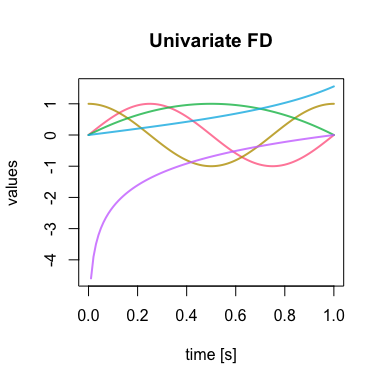

```r
plot( fD, main = 'Univariate FD', xlab = 'time [s]', ylab = 'values', lwd = 2 )
```

Thus, an object `fData` is a list containing: the fields `t0`, `tP`, defining the starting and end point of the one dimensional grid of the `fData` object, the constant step size `h` and the number of grid points `P` and the field `values` defining the measurements of the dataset over the one dimensional grid.

### mfData

An `mfData` object, instead, implements a multivariate functional dataset, i.e. a collection of functions having more than one components, each one depending on the same variable. In practice, we deal with a discrete grid $[t_0, t_1, \ldots, t_{P-1}]$ and a dataset of $N$ elements, each one having $L$ components observed over the same discrete grid: $D_{i,j,k} = X_{i,k}(t_{j-1})$, $\forall i = 1, \ldots, N$, $\forall j = 0, \ldots, P - 1$ and $\forall k = 1, \ldots, L$.

```r
# Creating some values for first component of the dataset
Data_1 = t( sapply( runif( 10, 0, 4 ),
                    function( phase ) sin( 2 * pi * grid + phase ) ) )

# Creating some values of functions for
Data_2 = t( sapply( runif( 10, 0, 4 ),
                    function( phase ) log( grid + phase ) ) )

# Building an fData object
# The constructor takes a grid and a list of matrix-like structures for data values,
# each one representing the data values of a single component of the dataset
# (i.e. D_{,,k}, k = 1, ... L ).
# (see help for more details on how to use the constructor)
mfD = mfData( grid, list( Data_1, Data_2 ) )

str( mfD )
```

```
## List of 6
##  $ N     : int 10
##  $ L     : int 2
##  $ P     : int 100
##  $ t0    : num 0
##  $ tP    : num 1
##  $ fDList:List of 2
##   ..$ :List of 6
##   .. ..$ t0    : num 0
##   .. ..$ tP    : num 1
##   .. ..$ h     : num 0.0101
##   .. ..$ P     : int 100
##   .. ..$ N     : int 10
##   .. ..$ values: num [1:10, 1:100] -0.25 -0.259 0.998 -0.148 0.815 ...
##   .. ..- attr(*, "class")= chr "fData"
##   ..$ :List of 6
##   .. ..$ t0    : num 0
##   .. ..$ tP    : num 1
##   .. ..$ h     : num 0.0101
##   .. ..$ P     : int 100
##   .. ..$ N     : int 10
##   .. ..$ values: num [1:10, 1:100] 1.2 1.14 1.21 1.35 -2.12 ...
##   .. ..- attr(*, "class")= chr "fData"
##  - attr(*, "class")= chr "mfData"
```

```r
# Each component of the mfData object is a fData object
sapply( mfD$fDList, class )
```

```
## [1] "fData" "fData"
```

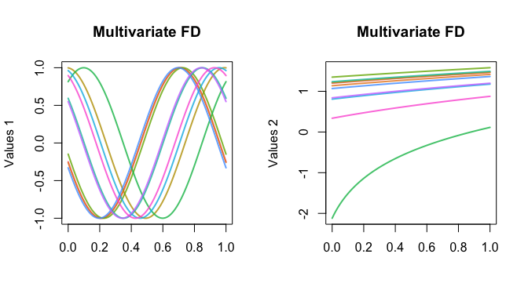

```r
plot( mfD, lwd = 2, main = 'Multivariate FD',
      xlab = 'time', ylab = list( 'Values 1', 'Values 2' ))
```

The fact that `mfData` components are `fData` obejcts is indeed conceptyally very natural, but also allows for a seamless application of `S3` methods meant for `fData` on multivariate functional data components, making the exploration and manipulation of multivariate datasets rather easy:

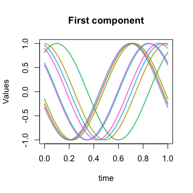

```r
plot( mfD$fDList[[ 1 ]], main = 'First component',
      xlab = 'time', ylab = 'Values', lwd = 2 )
```

Moreover, `mfData` objects can be obtained also from a set of homogeneous `fData` objects, i.e. of equal sample size and defined on the same grid:

```r
fD_1 = fData( grid, Data_1 )

fD_2 = fData( grid, Data_2 )

mfD = as.mfData( list( fD_1, fD_2 ) )

mfD = as.mfData( lapply( 1 : 10, function( i )( fD_1 ) ) )
```

### Subsetting fData

`fData` objects can be subset using a suitably overloaded operator `[.fData`, that allows for the use of standard slices of `matrix` and `array` classes also for `fData`.

```r
# Subsetting fData and returning result in matrix form
fD[ 1 , 1, as_fData = FALSE ]

fD[ 1, , as_fData = FALSE ]

fD[ 2, 10 : 20, as_fData = FALSE ]

fD[ , 10, as_fData = FALSE ]
```

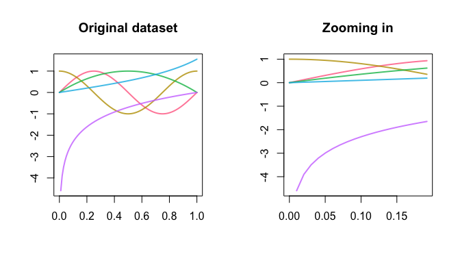

```r
# As default behaviour the subset is returned in fData form
par( mfrow = c(1,2) )
plot( fD, main = 'Original dataset', lwd = 2 )
plot( fD[ , 1 : 20 ], main = 'Zooming in', lwd = 2 )
```

### Algebra

An algebra of `fData` obejcts is also implemented, making it easy to sum, subtract, multiply and divide these objects by meaningful and compliant structures.

**Sums** and **subtractions**, available through `+` and `-` operators (see help at `+-.fData`), allow for sums of a `fData` on the left hand side and a compliant structure on the right hand side. This can be either another `fData` of same sample size and defined over the same grid, or a 1D/2D data structure with a number of columns equal `fData`’s grid length (i.e. `P`), and number of rows equal to `fData`’s sample size (i.e. `N`) or equal to one (in this case the only observation available is recycled `N` times). The operataions are then performed element-wise between the lhs and rhs.

```r
fD + fD

fD + matrix( 1, nrow = N, ncol = P )

fD + array( 2, dim = c( N, P ) )

fD + 1 : P
```

**Multiplication** and **division**, instead, is implemented only for an `fData` left hand side and a numeric variable or numeric vector right hand side. In the first case, each function in the functional dataset is multiplied/divided by the specified quantity; in the second case, specifying a vector of length `N`, the multiplication/division of each functional observation is carried out by the corresponding quantity in the vector, in an element-wise way:

```r
fD * 2

fD / 3

fD * ( 1 : N )

fD / ( 1 : N )
```

### Visualization

`fData` and `mfData` objects can be visualised thanks to specific `S3` plotting methods, `plot.fData` and `plot.mfData`.

The graphical parameters of these functions have been suitably customised in order to enhance the visualization of functions. In particular, as a default elements are plotted with continuous lines and an ad-hoc palette that helps differentiating them. As default x- and y-axis labels, as long as titles, are dropped so that plot’s arguments calls are not displayed when no value is provided.

In case of `mfData` the graphical window is split into a rectangular lattice to plot single dimensions. The rectangular frame has `floor( sqrt( L ) )` rows and `ceiling( x$L / floor( sqrt( x$L ) ) )` columns. If custom labels/titles are desired, they must be provided in the following way: since the grid is the same for all the dimensions, just one string is expected for x-axis (e.g. `xlab = 'grid'`), while either a single string or a list of `L` strings (one for each dimension) is expected for both the y-label(s) and title(s). In case just one string is passed to `plot.mfData`, the same value is used for all the dimensions.

## Statistics

### Depths

`roahd` provides a number of depth definitions, that are exploited by the visualization functions but can also be used by themselves. These are based on the notion of **Band Depth** (López-Pintado and Romo 2007; López-Pintado and Romo 2009).

**Band Depth** and **Modified Band Depth** are implemented in the functions `BD` and `MBD`. Both of them can work with either an `fData` object, specifying the univariate functional dataset whose depths must be computed, or a matrix of data values (e.g. in the form of `fData$values` output). `MBD` can be called with the additional parameters `manage_ties` (defaulting to `FALSE`), specifying whether a check for the presence of tied data must be made prior to computing depths, and therefore a suitable computing strategy must be used. The implementation of `MBD` exploits the recommendations of (Sun, Genton, and Nychka 2012), but extends them in order to accomodate for the possible presence of ties.

```r
  BD( fD )
  BD( fD$values )

  MBD( fD )
  MBD( fD$values )

  MBD( fD, manage_ties = TRUE )
  MBD( fD$values, manage_ties = TRUE )
```

Another definition avaibable is the **Half Region Depth** (along with its modified version), that is built on top of the **Epigraph** and **Hypograph** indexes (see López-Pintado and Romo 2011):

```r
HRD( fD )
HRD( fD$values )

MHRD( fD )
MHRD( fD$values )
```

A generalisation of MBD to multivariate functional data, implementing the ideas of Ieva and Paganoni (2013), is also available thorugh the functions `multiBD` and `multiMBD`. These functions accept either a `mfData` object, specifying the multivariate functional dataset whose depths have to be computed, or a list of matrices of data values (see example below).

The function computes the BD or MBD for each component of the multivariate functional dataset and then averages them accorging to a set of weights. These can be specified in two ways: either with the flag `uniform`, that is turned into `rep( 1/L, L )` (where `L` stands for the number of components in the multivariate dataset), or by providing the actual set of weights to be used. The latter option allows to use ad-hoc set of weights, like in (Tarabelloni et al. 2015).

```r
  multiBD( mfD, weights = 'uniform' )
  multiMBD( mfD, weights = 'uniform', manage_ties = FALSE )

  multiBD( mfD, weights = c( 0.6, 0.4) )
  multiMBD( mfD, weights = c( 0.7, 0.3 ), manage_ties = FALSE )

  multiBD( list( fD_1$values, fD_2$values ), weights = c( 0.6, 0.4) )
  multiMBD( list( fD_1$values, fD_2$values ), weights = c( 0.7, 0.3 ), manage_ties = FALSE )
```

### Mean and median

Suitable `S3` extensions to the functions for the computation of mean function and median of functional datasets are also present.

The sample mean of a functional dataset coincides with the *cross-sectional* mean function, i.e. the function obtained by computing the mean across the whole dataset point-by-point along the grid where functional data are defined:

$$\widehat{\mu}( t_j ) = \dfrac{1}{N} \sum_{i=1}^{N} X_i(t_j), \qquad \forall j = 0, \ldots, P-1$$

for a univariate functional dataset, while in the multivariate case is:

$$\widehat{\mu}_k(t_j) = \dfrac{1}{N} \sum_{i=1}^{N} X_{i,k}(t_j), \qquad \forall j = 0, \ldots, P-1,
\qquad \forall k = 1, \ldots, L.$$

The sample median of a functional dataset, instead, is defined as the element of the functional dataset fulfilling the maximum depths, given a certain definition of depth. For instance, for MBD:

$$\widehat{m}( t_j ) = \left(\text{arg}\max_{i=1, \ldots, N} MBD( X_i )\right)( t_j), \qquad j = 0, \ldots, P-1.$$

The sample mean is implemented in the `S3` methods `mean.fData( x, ... )` and `mean.mfData( x, ... )`, that can be invoked directly on `fData` and `mfData` objects. The sample median, instead, is implemented in the functions `median_fData( fData, type = 'MBD', ... )` and `median_mfData( mfData, type = 'multiMBD', ... )`. Here, the `type` flag can take any name of functions (available in the caller’s environment) that can be used to compute the depths defining the sample median, taking respectively a 2D matrix of data values and a list of 2D matrix of data values as argument (plus, optionally, the dots arguments).

```r
  mean( fD )
  mean( mfD)

  median_fData( fD, type = 'MBD' )
  median_fData( fD, type = 'MHRD' )
```

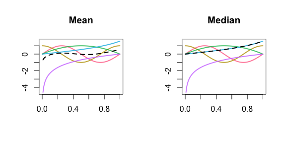

```r
  par( mfrow = c(1,2) )
  plot( fD, main = 'Mean', lwd = 2 )
  plot( mean( fD ), add = TRUE, lwd = 2, col = 'black', lty = 2 )

  plot( fD, main = 'Median', lwd = 2 )
  plot( median_fData( fD, type = 'MBD' ), add = TRUE, lwd = 2, lty = 2, col = 'black' )
```

### Indexes

`roahd` collects the implementation of some useful indexes that can be used to describe and summarise functional datasets.

`EI` and `MEI` implement the **Epigraph Index** and the **Modified Epigraph Index**, while `HI` and `MHI` implement the **Hypograph Index** and the **Modified Hypograph Index** (see López-Pintado and Romo 2011; Arribas-Gil and Romo 2014). These indexes can be used to sort data, respectively, in a top-down and bototm-up fashion, and are used to define the HRD/MHRD and to build the outliegram.

These `S3` methods can be called on univariate functional datasets, provided either in form of a `fData` object or a 2D matrix of values.

```r
  # Calling on fData objects
  EI( fD )
  MEI( fD )

  HI( fD )
  MHI( fD )

  # Calling on 2D matrix type objects
  EI( fD$values )
  EI( matrix( rnorm( 20 ), nrow = 4, ncol = 5 ) )
```

### Correlation coefficients

The function `cor_kendall( mfD, ordering = 'max' )` allows to compute the Kendall’s tau correlation coefficient between components of a bivariate dataset. The function accepts a `mfData` object and a criterion to perform the ordering of functional data (this ordering is used to determine the concordances and discordacnes between pairs in the definition of the coefficient).

Two criteria are available so far, that directly reflect those proposed in the reference paper: `max`, for the ordering between maxima of functions, and `area`, for the ordering between area-under-the-curve of functions.

```r
  N = 10
  P = 1e3

  grid = seq( 0, 1, length.out = P )

  Data_1 = t( sapply( 1 : N, function( i )( sin( 2 * pi * grid ) + i ) ) )
  # Monotone nonlinear transformation of data
  Data_2 = Data_1^3

  mfD = mfData( grid, list( Data_1, Data_2 ) )
```

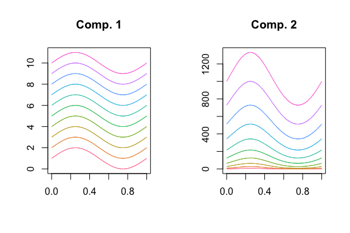

```r
  plot( mfD, main = list( 'Comp. 1', 'Comp. 2') )
```

```r
  # Kendall correlation of monotonically dependent data is exactly 1
  cor_kendall( mfD, ordering = 'max' )
## [1] 1
  cor_kendall( mfD, ordering = 'area' )
## [1] 1
```

The function `cor_spearman( mfD, ordering = 'MEI', ... )` can be used to compute the Spearman correlation coefficient for a bivariate `mfData` object, uning the ordering policy specified by `ordering` (defaulting to `MEI`) to rank univariate compoenents and then compute the correlation coefficient. Besides `MEI`, also `MHI` can be used to determine ranks of univariate components. Additional parameters captured by `...` are passed directly to the rank function.

```r
# Spearman correlation of monotonically dependent data is exactly 1
  cor_spearman( mfD, ordering = 'MEI' )
## [1] 1
  cor_spearman( mfD, ordering = 'MHI' )
## [1] 1
```

## Simulation of functional data

`roahd` contains also some functions that can be used to simulate artificial data sets of functional data, both univariate and multivariate. These are used in the adjustment procedure of the outliegram and functional boxplot, but can also be used to help the development of new methodologies and help their testing.

Artificial univariate data are obtained simulating realisations of a gaussian process over a discrete grid with a specific covariance function and center (e.g. mean or median). Given a covariance function, $C(s,t)$ and a centerline $m(t)$, the model generating data is:
$$X_i(t) = m(t) + \epsilon(t), \quad Cov(\epsilon(s),\epsilon(t)) = C(s,t), \quad i = 1, \ldots, N.$$

### Univariate functional data

The function `generate_gauss_fdata(N, centerline, Cov = NULL, CholCov = NULL)` can be used to simulate a population of such gaussian functional data. The required arguments are: `N` the number of elements to be generated; `centerline`, the center of the distribution (mean or median); `Cov`, a matrix representation of the desired covariance function, meant as the measurements of such function over a tensor grid whose marginal will be the grid where the functional data will be defined (i.e. the argument `grid` in `fData`); `CholCov` the Cholesky factor of the discrete representation of the Covariance function over the tensor grid (optional and alternative to the argument `Cov`). The inner procedure to generate the synthetic population of gaussian functional data makes use of the Cholesky factor of `Cov`, hence by providing its Cholesky factor, if already present in the caller’s scope, can save computing time.

A built-in function can be used to generate exponential-like covariance functions, namely `exp_cov_function( grid, alpha, beta )`, generating the discretised version of a covariance of the form $C(s,t) = \alpha e^{-\beta | s - t | }$ over a lattice given by the tensorisation of grid in `grid`.

A comprehensive example is the following:

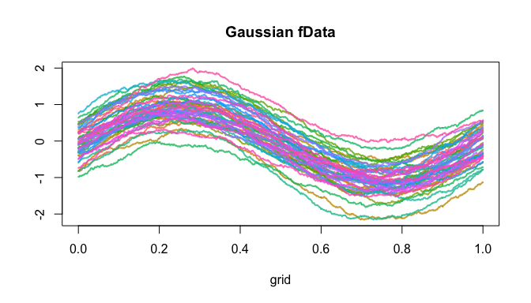

```r
  N = 50
  P = 1e3

  grid = seq( 0, 1, length.out = P )

  Cov = exp_cov_function( grid, alpha = 0.2, beta  = 0.3 )

  Data = generate_gauss_fdata( N, centerline = sin( 2 * pi * grid ), Cov = Cov )

  fD = fData( grid, Data )

  plot( fD, main = 'Gaussian fData', xlab = 'grid', lwd = 2)
```

### Multivariate functional data

The function `generate_gauss_mfdata( N, L, centerline, correlations, listCov = NULL, listCholCov = NULL)` can be used to generate a gaussian dataset of multivariate functional data. The model generating data is the following:

$$X_{i,k} = m_k(t) + \epsilon_k(t), \quad Cov(\epsilon_k(s),\epsilon_k(t))=C(s,t), \quad
\forall i = 1, \ldots, N, \quad \forall k = 1, \ldots, L,$$

where $Cor( \epsilon_j(t),\epsilon_l(t))=\rho_{j,l}$ specifies a (*synchronous*) correlation structure among the compoenents of the functional dataset.

In order to use the function one should provide: `N`, the number of elelemnts to simulate; `L`, the number of components of the functional data; `centerline`, a matrix containing (by rows) the centerline for each component; `correlations`, a vector of length `1/2 * L * ( L - 1 )`, containing all the correlation coefficients among the components; either `listCov` or `listCholCov`, a list containing either the discretised covariance functions over the tensorised grid where functional data will be defined), or their Cholesky factor.

A comprehensive example is the following:

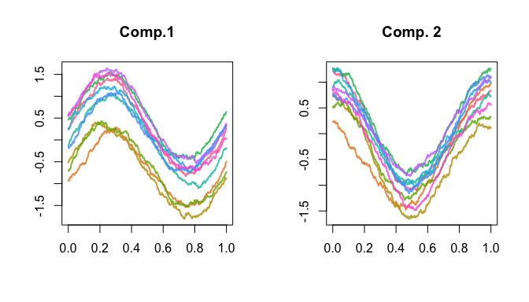

```r
  N = 10
  P = 1e3

  grid = seq( 0, 1, length.out = P )

  Cov_1 = exp_cov_function( grid, alpha = 0.1, beta  = 0.5 )
  Cov_2 = exp_cov_function( grid, alpha = 0.5, beta = 0.1)

  centerline = matrix( c( sin( 2 * pi * grid ),
                          cos( 2 * pi * grid ) ), nrow = 2, byrow = TRUE )

  Data = generate_gauss_mfdata( N, 2, centerline, 0.8, list( Cov, Cov ) )

  mfD = mfData( grid, Data )

  plot( mfD, main = list( 'Comp.1', 'Comp. 2'), xlab = 'grid', lwd = 2)
```

## Robustification

### Functional boxplot

An implementation of the functional boxplot, through the `S3` method `fbplot`, allows for the detection of *amplitude* outliers in univariate and multivariate functional datasets (see Sun and Genton 2011).

`fbplot` can be used to compute the set of indices inside a dataset marking outlying observations. If used in graphical way (default behaviour), it also plots the functional boxplot of the dataset provided.

The functional boxplot is obtained by ranking functions from the center of the distribution outwards thanks to a depth definition, computing the region of 50% most central functions and inflating such region by a factor `F`. Whichever function crossing these boundaries is flagged as outlier. The default value for `F` is `1.5`, otherwise it can be set with the argument `Fvalue`.

The argument `Depths` can take either the name of the function to call in order to compute the depths (default is `MBD`), or a vector containing the dephts values for the provided dataset.

An example is:

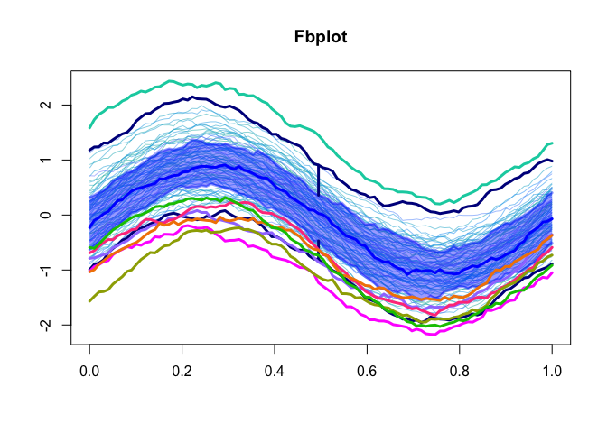

```r
  set.seed(1618)

  N = 1e2
  P = 1e2

  grid = seq( 0, 1, length.out = P )

  Cov = exp_cov_function( grid, alpha = 0.2, beta = 0.3 )

  Data = generate_gauss_fdata( N, sin( 2 * pi * grid ), Cov )

  fD = fData( grid, Data )

  Data = generate_gauss_mfdata( N, 2, matrix( sin( 2 * pi * grid ), nrow = 2, ncol = P, byrow = TRUE ), 0.6, listCov = list( Cov, Cov ) )

  mfD = mfData( grid, Data )

  fbplot( fD, main = 'Fbplot', Fvalue = 3.5 )
```

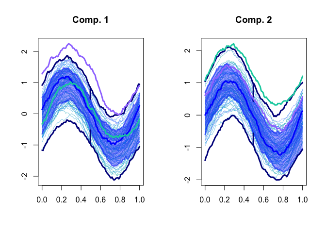

```r
  fbplot( mfD, main = list( 'Comp. 1', 'Comp. 2' ), Fvalue = 3.5 )
```

The method `fboplot.fData` also allows to automatically compute the best adjustment factor `F` that yields a desired proportion of outliers (True Positive Rate, `TPR`) out of a Gaussian dataset with same center and covariance function as the `fData` object (see Sun and Genton 2012).

Such automatic tuning involves the simulation of a number `N_trials` of populations of Gaussian functional data with same center and covariance as the original dataset (the covariance is robustly estimated with `robustbase::covOGK`) of size `trial_size`, and the computation of `N_trials` values for `Fvalue` such that the desired proportion `TPR` of observations is flagged as outliers. The optimal value of `Fvalue` for the original population is then found as the average of the previously computed values `Fvalue`. The computation of the optimal `Fvalue` at each iteration of the procedure is carried out exploiting the zero-finding algorithm in `stats::uniroot` (Brent’s method).

The parameters to control the adjustment procedure can be passed through the argument `adjust`, whose default is `FALSE` and otherwise is a list with (some of) the fields:

- `N_trials`: the number of repetitions of the adujustment procedure based on the simulation of a gaussisan population of functional data, each one producing an adjusted value of F, which will lead to the averaged adjusted value `Fvalue`. Default is 20;
- `trial_size`: the number of elements in the gaussian population of functional data that will be simulated at each repetition of the adjustment procedure. Default is `Data$N`;
- `TPR`: the True Positive Rate of outliers, i.e. the proportion of observations in a dataset without amplitude outliers that have to be considered outliers. Default is `2 * pnorm( 4 * qnorm( 0.25 ) )`;
- `F_min`: the minimum value of `Fvalue`, defining the left boundary for the optimisation problem aimed at finding, for a given dataset of simulated gaussian data associated to Data, the optimal value of `Fvalue`. Default is `0.5`;
- `F_max`: the maximum value of `Fvalue`, defining the right boundary for the optimisation problem aimed at finding, for a given dataset of simulated gaussian data associated to Data, the optimal value of `Fvalue`. Default is `5`;
- `tol`: the tolerance to be used in the optimisation problem aimed at finding, for a given dataset of simulated gaussian data associated to Data, the optimal value of `Fvalue`. Default is `1e-3`;
- `maxiter`: the maximum number of iterations to solve the optimisation problem aimed at finding, for a given dataset of simulated gaussian data associated to `Data`, the optimal value of `Fvalue`. Default is `100`;
- `VERBOSE`: a parameter controlling the verbosity of the adjustment process;

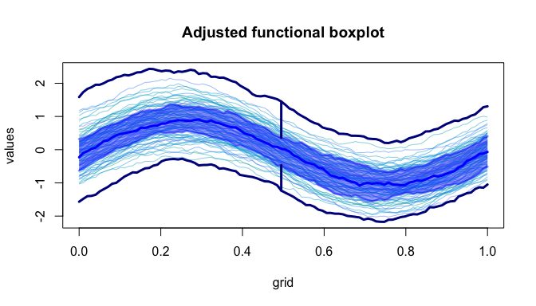

```
## $Depth
##   [1] 0.38385859 0.49394343 0.34525657 0.42096162 0.13828283 0.35837576
##   [7] 0.28715152 0.32094949 0.32032323 0.48111919 0.31599192 0.21463030
##  [13] 0.50012525 0.42326869 0.48843232 0.20121616 0.50892929 0.47389091
##  [19] 0.20728889 0.47252121 0.06370909 0.33557576 0.15535354 0.47672727
##  [25] 0.47752323 0.42835152 0.46382222 0.22322020 0.47668687 0.35484848
##  [31] 0.33292929 0.08008485 0.25306667 0.44199192 0.02651717 0.44075556
##  [37] 0.47486869 0.15956768 0.29795556 0.29344242 0.29510303 0.16485657
##  [43] 0.16455758 0.17609293 0.45211717 0.05358384 0.48465051 0.38964040
##  [49] 0.21711515 0.33858990 0.19272727 0.47710707 0.34191515 0.40525657
##  [55] 0.22770505 0.10705051 0.39230303 0.29587071 0.33210101 0.45514747
##  [61] 0.49753939 0.49472727 0.44715152 0.36111515 0.33575354 0.22018586
##  [67] 0.49524040 0.49006465 0.41932121 0.44806869 0.39192727 0.27018182
##  [73] 0.48225051 0.46254141 0.27178182 0.40633131 0.40986263 0.09875152
##  [79] 0.47945051 0.47055758 0.35553535 0.47608889 0.05703434 0.39505859
##  [85] 0.18181010 0.12517172 0.43975758 0.30673535 0.47002020 0.44986263
##  [91] 0.47310707 0.02000000 0.28471919 0.47399192 0.50324444 0.46288485
##  [97] 0.38802424 0.36598788 0.41559596 0.49222626
##
## $Fvalue
## [1] 5.828683
##
## $ID_outliers
## integer(0)
```

```r
  fbplot( fD, adjust = list( N_trials = 20, trial_size = N, TPR = 0.007, F_min = 0.1, F_max = 20 ), xlab = 'grid', ylab = 'values', main = 'Adjusted functional boxplot' )
```

### Outliergram

A method that can be used to detect **shape outliers** is the outliergram (see Arribas-Gil and Romo 2014), based on the computation of MBD and MEI of univariate functional data. Such pairs are compared to a limiting parabola, where they should be placed in case of non-crossing data, and outliers are then identified applying a thresholding rule.

The function `outliergram` displays the outliergram of a univariate functional dataset of class `fData`, and returns a vector of IDs indicating the shape outlying observations in the dataset.

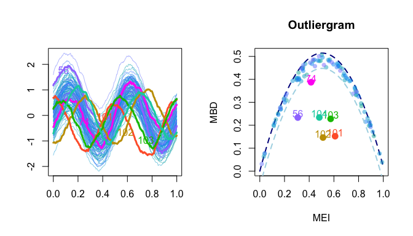

```
## $Fvalue
## [1] 1.5
##
## $ID_outliers
## [1]  56  74 101 102 103 104
```

```r
set.seed( 1618 )

N = 100
P = 200
N_extra = 4

grid = seq( 0, 1, length.out = P )

Cov = exp_cov_function( grid, alpha = 0.2, beta = 0.5 )

Data = generate_gauss_fdata( N, sin( 4 * pi * grid ), Cov )

Data_extra = array( 0, dim = c( N_extra, P ) )

Data_extra[ 1, ] = generate_gauss_fdata( 1, sin( 4 * pi * grid + pi / 2 ), Cov )

Data_extra[ 2, ] = generate_gauss_fdata( 1, sin( 4 * pi * grid - pi / 2 ), Cov )

Data_extra[ 3, ] = generate_gauss_fdata( 1, sin( 4 * pi * grid + pi/ 3 ), Cov )

Data_extra[ 4, ] = generate_gauss_fdata( 1, sin( 4 * pi * grid - pi / 3), Cov )

fD = fData( grid, rbind( Data, Data_extra ) )

outliergram( fD, display = TRUE )
```

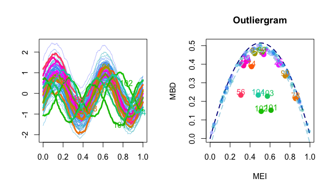

```
## $Fvalue
## [1] 5
##
## $ID_outliers
##  [1]   6  25  27  30  41  56  74  78  90  91  99 101 102 103 104
```

```r
outliergram( fD, Fvalue = 5, display = TRUE )
```

Similarly to the functional boxplot, also the outliergram makes use of an `Fvalue` constant controlling the check by which observations are flagged as outliers (see Arribas-Gil and Romo 2014 for more details). Such value can be provided as an argument (default is `1.5`), or can be determined by the function itself, through an adjustment procedure similar to that of `fbplot.fData`. In particolar, whenever `adjust` is not `FALSE`, `adjust` should be a list containing the fields controlling the adjustment:

- `N_trials` the number of repetitions of the adujustment procedure based on the simulation of a gaussisan population of functional data, each one producing an adjusted value of `Fvalue`, which will lead to the averaged adjusted value. Default is `20`;
- `trial_size` the number of elements in the gaussian population of functional data that will be simulated at each repetition of the adjustment procedure. Default is `5 * fData$N`;
- `TPR` the True Positive Rate of outleirs, i.e. the proportion of observations in a dataset without shape outliers that have to be considered outliers. Default is `2 * pnorm( 4 * qnorm( 0.25 ) )`;
- `F_min` the minimum value of `Fvalue`, defining the left boundary for the optimisation problem aimed at finding, for a given dataset of simulated gaussian data associated to `fData`, the optimal value of `Fvalue`. Default is `0.5`;
- `F_max` the maximum value of `Fvalue`, defining the right boundary for the optimisation problem aimed at finding, for a given dataset of simulated gaussian data associated to `fData`, the optimal value of `Fvalue`. Default is `20`;}
- `tol` the tolerance to be used in the optimisation problem aimed at finding, for a given dataset of simulated gaussian data associated to `fData`, the optimal value of `Fvalue`. Default is `1e-3`;
- `maxiter` the maximum number of iterations to solve the optimisation problem aimed at finding, for a given dataset of simulated gaussian data associated to `fData`, the optimal value of `Fvalue`. Default is `100`;
- `VERBOSE` a parameter controlling the verbosity of the adjustment process;

```r
outliergram( fD, adjust = list( N_trials = 5, trial_size = 5 * nrow( Data ), TPR = 0.01, VERBOSE = FALSE ), display = TRUE )
```

[figure not shown]

[output not shown]

## References

Arribas-Gil, A., and J. Romo. 2014. “Shape Outlier Detection and Visualization for Functional Data: The Outliergram.” *Biostatistics* 15 (4): 603–19.

Ieva, F., and A.M. Paganoni. 2013. “Depth Measures for Multivariate Functional Data.” *Communication in Statistics - Theory and Methods* 42 (7): 1265–76.

López-Pintado, S., and J. Romo. 2007. “Depth-Based Inference for Functional Data.” *Computational Statistics & Data Analysis* 51 (10): 4957–68.

———. 2009. “On the Concept of Depth for Functional Data.” *Journal of the American Statistical Association* 104 (486): 718–34.

———. 2011. “A Half-Region Depth for Functional Data.” *Computational Statistics & Data Analysis* 55 (4): 1679–95.

Sun, Y., and M. G. Genton. 2011. “Functional Boxplots.” *Journal of Computational and Graphical Statistics* 20 (2): 316–34.

———. 2012. “Adjusted Functional Boxplots for Spatio-Temporal Data Visualization and Outlier Detection.” *Environmetrics* 23 (1): 54–64.

Sun, Y., M. G. Genton, and D. W. Nychka. 2012. “Exact Fast Computation of Band Depth for Large Functional Datasets: How Quickly Can One Million Curves Be Ranked?” *Stat* 1 (1): 68–74.

Tarabelloni, N., F. Ieva, R. Biasi, and A.M. Paganoni. 2015. “Use of Depth Measure for Multivariate Functional Data in Disease Prediction: An Application to Electrocardiograph Signals.” *The International Journal of Biostatistics* 11 (2): 189–201.